# Happiness

David Parsons

February 10, 2017

[Rutgers Data 101 Blog](http://data101.cs.rutgers.edu/?q=blog)

My Data Exploration Homepage

[Rutgers Data 101 Homepage](http://data101.cs.rutgers.edu/)

## Introduction

This investigation is in response to a course assignment for my CS 142 class. We we’re provided with a synthetic data set that had artificial patterns created with in it for us to find.

## The Data

Data Provided by Professor Imenlinski as part of a CS 142 Assignment.

```r
hap <- read.csv("HAPPINESS2017.csv")

hap[,8] <- ""
colnames(hap)[8] <- "GEN"
hap$GEN <-  cut(hap$AGE, 5, c("Young", "Adult", "Middle Adult", "Older Adult", "Elderly"))

summary(hap)
```

```
##       IDN             AGE                 COUNTRY        GENDER
##  Min.   :10001   Min.   :18.00   Burundi      :  55   Female:3218
##  1st Qu.:31920   1st Qu.:31.00   Swaziland    :  55   Male  :3212
##  Median :53989   Median :44.00   United States:  54
##  Mean   :54637   Mean   :44.04   Jordan       :  52
##  3rd Qu.:77854   3rd Qu.:57.00   Vietnam      :  52
##  Max.   :99981   Max.   :70.00   Bolivia      :  51
##                                  (Other)      :6111
##    IMMIGRANT          INCOME         HAPPINESS               GEN
##  Min.   :0.0000   Min.   : 23809   Min.   :1.270   Young       :1317
##  1st Qu.:0.0000   1st Qu.: 47304   1st Qu.:3.700   Adult       :1223
##  Median :0.0000   Median : 69254   Median :5.660   Middle Adult:1349
##  Mean   :0.1171   Mean   : 70003   Mean   :5.845   Older Adult :1214
##  3rd Qu.:0.0000   3rd Qu.: 93176   3rd Qu.:7.630   Elderly     :1327
##  Max.   :1.0000   Max.   :117248   Max.   :9.920
##
```

```r
vars = colnames(hap)
```

Each data point was representative of a single person and how they fit into the following:

```
Idn (unique ID)
Age
Country (Spouse Origin)
Gender
Immigrant (Binary Immigrant status 1 -> Yes, 0 -> No)
Income
Happiness ("Happiness" Level from 1 - 10)
```

## Investigation

The following is the step by step thought process I followed in exploring this data set and arriving at the conclusion I did.

### Happiness, Income, & Age

I started by creating a scatter plot of each respondents Happiness against both Income and Age

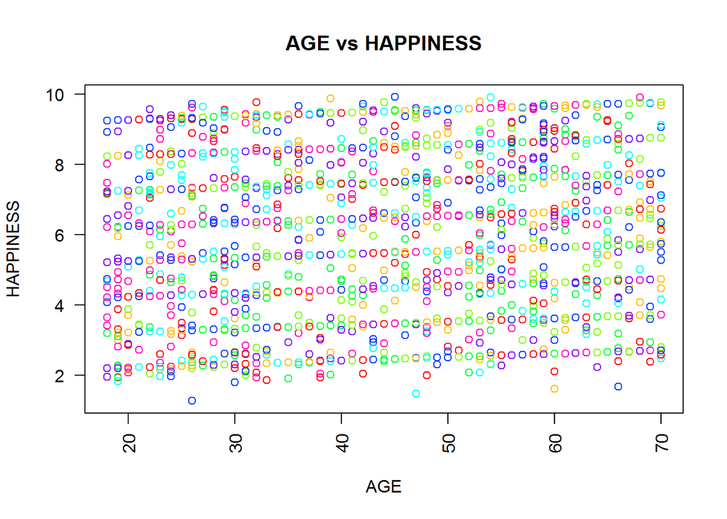

```r
scatPlot <- function(x, y, frm){

  title = paste(x,y, sep = " vs ")
  plot(frm[,x], frm[,y], col = rainbow(8), main = title, las = 2, xlab = x, ylab = y)
}

scatPlot("AGE", "HAPPINESS", hap)
```

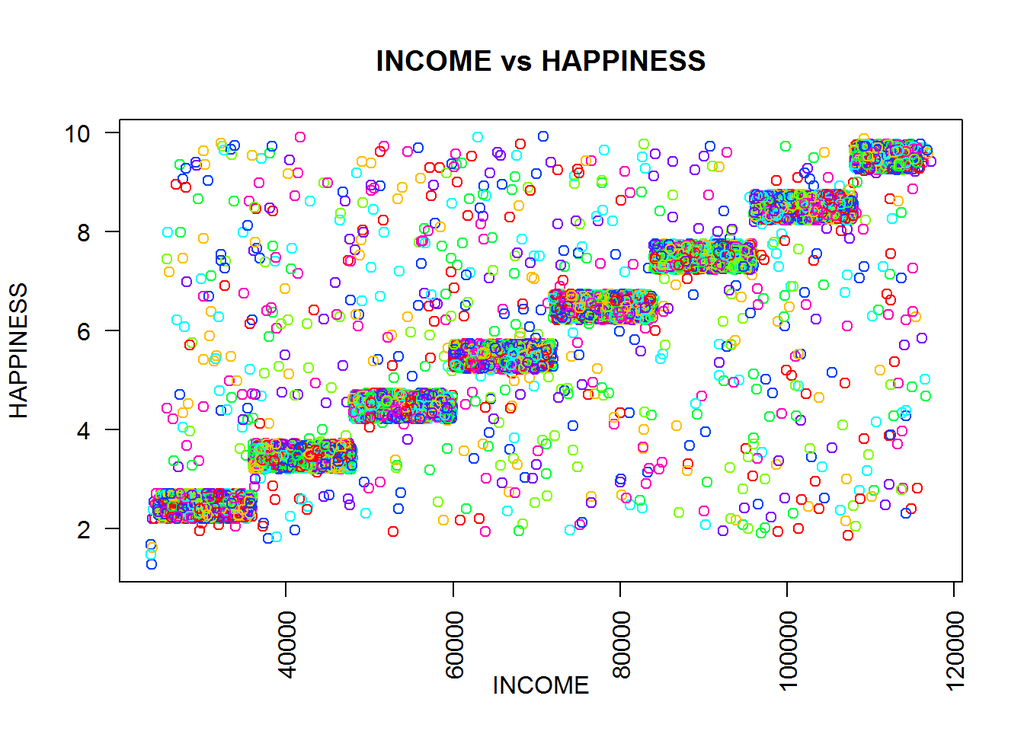

```r
scatPlot("INCOME", "HAPPINESS", hap)
```

Age vs Happiness revealed no correlations, Age appears to have no direct effect upon a person’s happiness.

But Income vs Happiness shows clear increase in happiness as income increases.

### Income & Happiness “Classes”

Now I wanted to define what Ranges or classes exist within Happiness and Income.

I spent more time than I’d like to admit, brute forcing the ranges until the scatter plot was void of those with a Happiness Level equal to their income level.

I knew just from looking at the graph that there were 8 distinct level for both, and rather than trying to use R functions that I didn’t fully understand, I just changed the ranges and re-plotted the data adjusting based of the visual data. I should have poured over some documentation and learned how get R to do it for me (the whole point of these projects), but after failing with cut and pretty, I just brute forced it and called it a night. I’ll read the R docs when I have to do this in the future.

But in the end I wound up with these new categories and this new subset of data after I removed those with Happiness Levels equal to their Income levels.

```r
hap[,9] <- ""
colnames(hap)[9] <- "INCLEVEL"
classes = c("8th", "7th", "6th", "5th", "4th", "3rd", "2nd", "1st")
hap$INCLEVEL <-  cut(hap$INCOME, breaks = c(0, 36000, 47999, 59999, 72000, 84000, 96000, 108000, 120000), classes)


hap[,10] <- ""
colnames(hap)[10] <- "HAPLEVEL"
classes = c("8th", "7th", "6th", "5th", "4th", "3rd", "2nd", "1st")
hap$HAPLEVEL <-  cut(hap$HAPPINESS, breaks = c(0, 3, 4, 5, 6, 7, 8, 9, 10), classes)

summary(hap)
```

```
##       IDN             AGE                 COUNTRY        GENDER
##  Min.   :10001   Min.   :18.00   Burundi      :  55   Female:3218
##  1st Qu.:31920   1st Qu.:31.00   Swaziland    :  55   Male  :3212
##  Median :53989   Median :44.00   United States:  54
##  Mean   :54637   Mean   :44.04   Jordan       :  52
##  3rd Qu.:77854   3rd Qu.:57.00   Vietnam      :  52
##  Max.   :99981   Max.   :70.00   Bolivia      :  51
##                                  (Other)      :6111
##    IMMIGRANT          INCOME         HAPPINESS               GEN
##  Min.   :0.0000   Min.   : 23809   Min.   :1.270   Young       :1317
##  1st Qu.:0.0000   1st Qu.: 47304   1st Qu.:3.700   Adult       :1223
##  Median :0.0000   Median : 69254   Median :5.660   Middle Adult:1349
##  Mean   :0.1171   Mean   : 70003   Mean   :5.845   Older Adult :1214
##  3rd Qu.:0.0000   3rd Qu.: 93176   3rd Qu.:7.630   Elderly     :1327
##  Max.   :1.0000   Max.   :117248   Max.   :9.920
##
##     INCLEVEL       HAPLEVEL
##  5th    : 887   2nd    : 856
##  7th    : 865   3rd    : 854
##  2nd    : 861   5th    : 848
##  6th    : 838   7th    : 847
##  3rd    : 832   6th    : 839
##  4th    : 822   4th    : 826
##  (Other):1325   (Other):1360
```

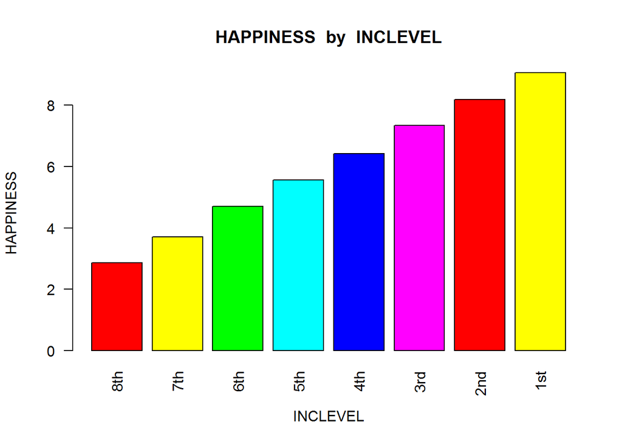

```r
plotBar <- function(frm, val, cat){

  frm.mean <- tapply(frm[,val], frm[,cat], mean)
  barplot(frm.mean, las = 2, main=paste(val, " by ", cat), xlab = cat, ylab = val, col = rainbow(6), las = 2)
}

plotBar(hap, "HAPPINESS", "INCLEVEL")
```

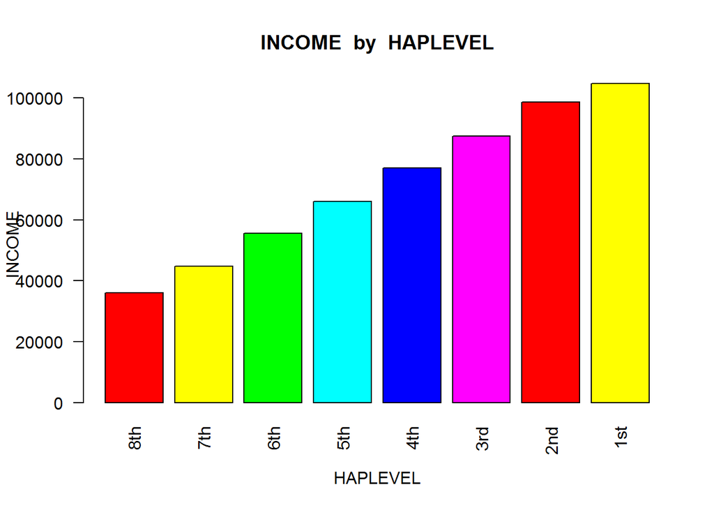

```r
plotBar(hap, "INCOME", "HAPLEVEL")
```

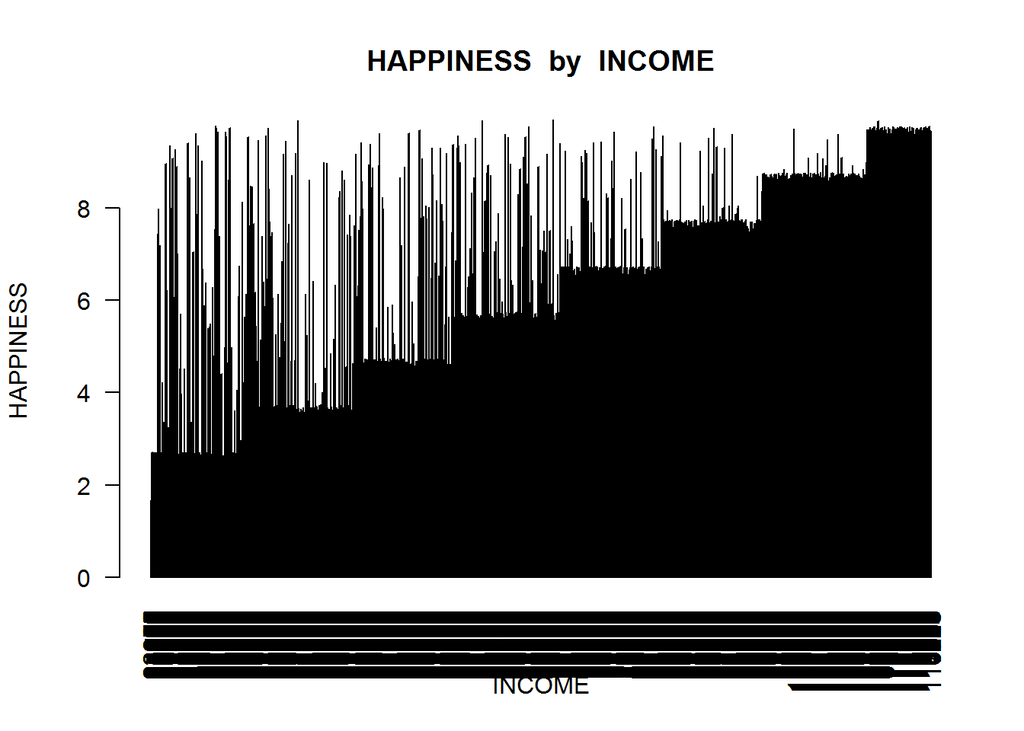

```r
plotBar(hap, "HAPPINESS", "INCOME")
```

These bar graphs confirm the clear correlation between an increase in Income and Happiness.

The graph looks almost like a set of stairs. Each step is an increase in Income and it correlates to an increase in “Happiness” and vice versa.

But now I am interested in those outliers, that didn’t fit into the steps.

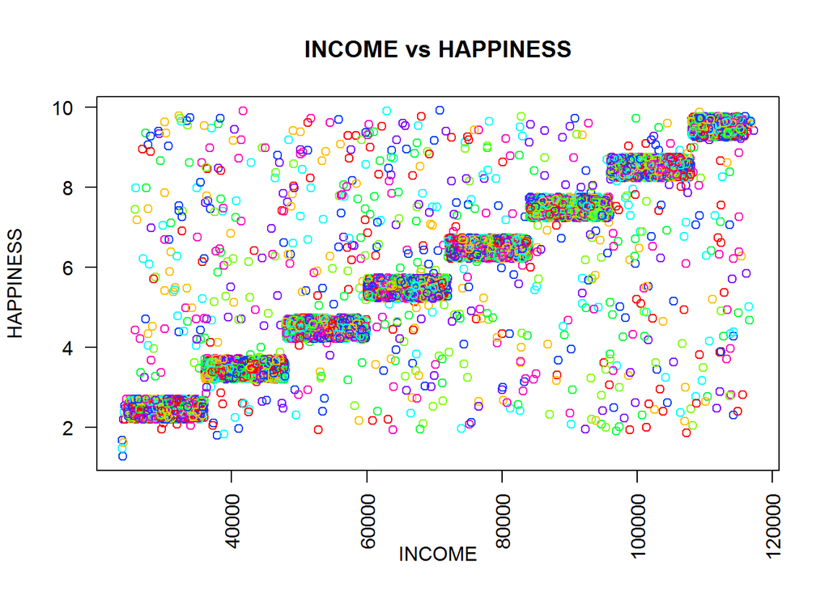

```r
# Original Set
scatPlot("INCOME", "HAPPINESS", hap)
```

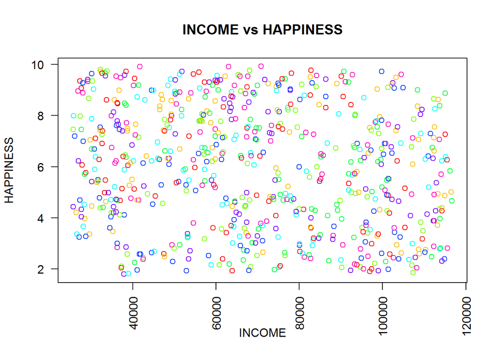

```r
# Set with the with the same Income & Happiness Levels removed
scatPlot("INCOME", "HAPPINESS", subset(hap, INCLEVEL != HAPLEVEL))
```

The First graph is the original scatter plot, while the second is only the outliers.

Now it’s time for me to figure more out about these outliers.

### Outliers

I first define a specific subset for the outliers.

Then I ran the same graphs I ran for the original set.

```r
hap.outliers = subset(hap, INCLEVEL != HAPLEVEL)
summary(hap.outliers)
```

```
##       IDN             AGE                 COUNTRY       GENDER
##  Min.   :10083   Min.   :18.00   Kuwait       : 13   Female:327
##  1st Qu.:31689   1st Qu.:29.25   Oman         : 13   Male  :331
##  Median :51683   Median :44.00   United States: 12
##  Mean   :53152   Mean   :43.49   Australia    : 11
##  3rd Qu.:76866   3rd Qu.:57.00   Costa Rica   : 11
##  Max.   :99581   Max.   :70.00   Ireland      : 11
##                                  (Other)      :587
##    IMMIGRANT     INCOME         HAPPINESS               GEN
##  Min.   :1   Min.   : 25694   Min.   :1.800   Young       :150
##  1st Qu.:1   1st Qu.: 47686   1st Qu.:4.082   Adult       :123
##  Median :1   Median : 67798   Median :6.190   Middle Adult:128
##  Mean   :1   Mean   : 69599   Mean   :5.982   Older Adult :131
##  3rd Qu.:1   3rd Qu.: 93295   3rd Qu.:7.973   Elderly     :126
##  Max.   :1   Max.   :116649   Max.   :9.920
##
##     INCLEVEL      HAPLEVEL
##  5th    :103   8th    : 94
##  6th    : 91   6th    : 92
##  2nd    : 86   3rd    : 92
##  7th    : 85   4th    : 89
##  4th    : 85   2nd    : 81
##  8th    : 81   1st    : 79
##  (Other):127   (Other):131
```

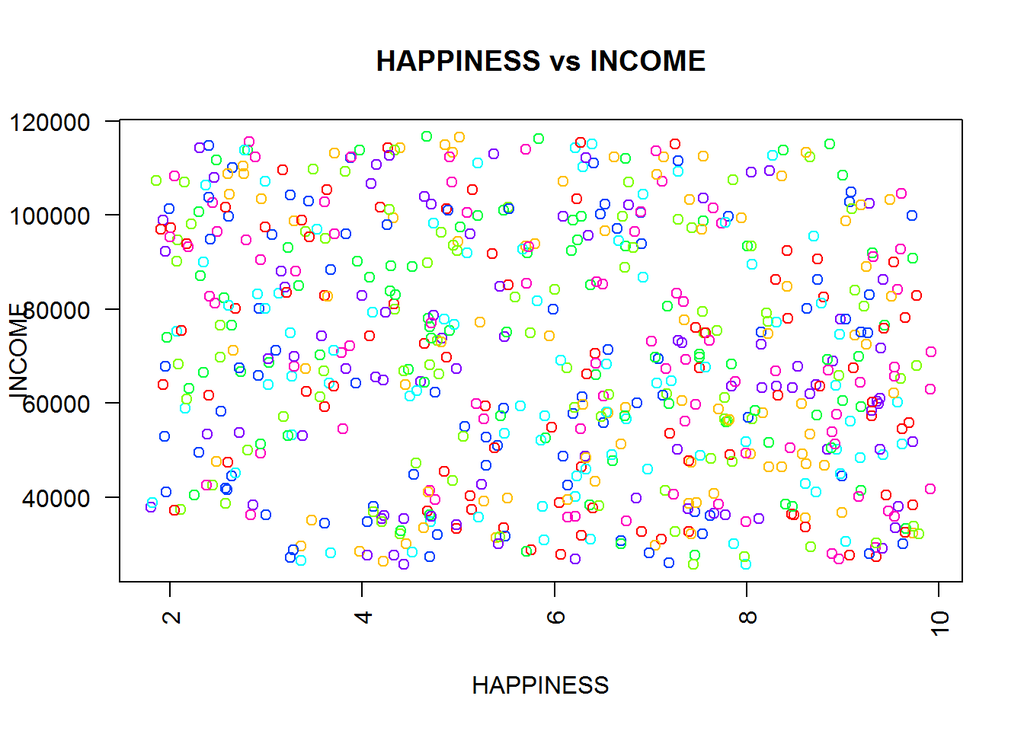

```r
scatPlot("HAPPINESS", "INCOME", hap.outliers)
```

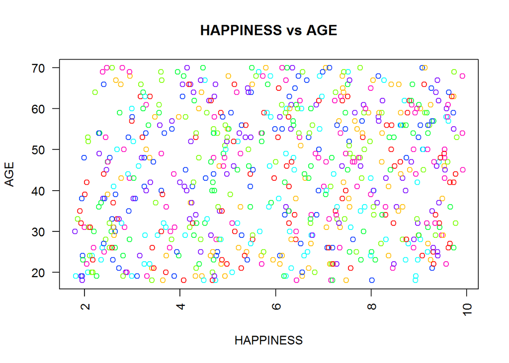

```r
scatPlot("HAPPINESS", "AGE", hap.outliers)
```

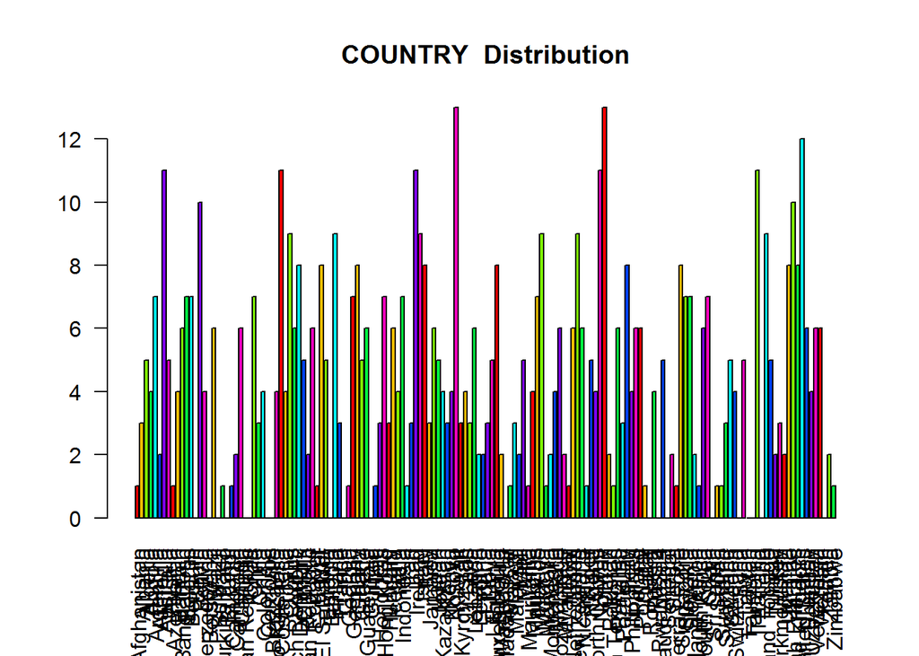

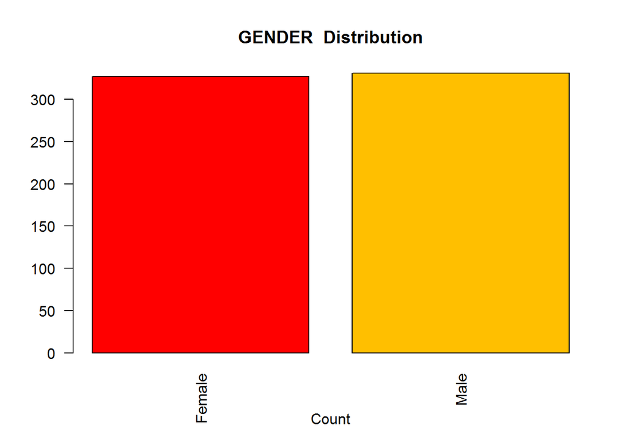

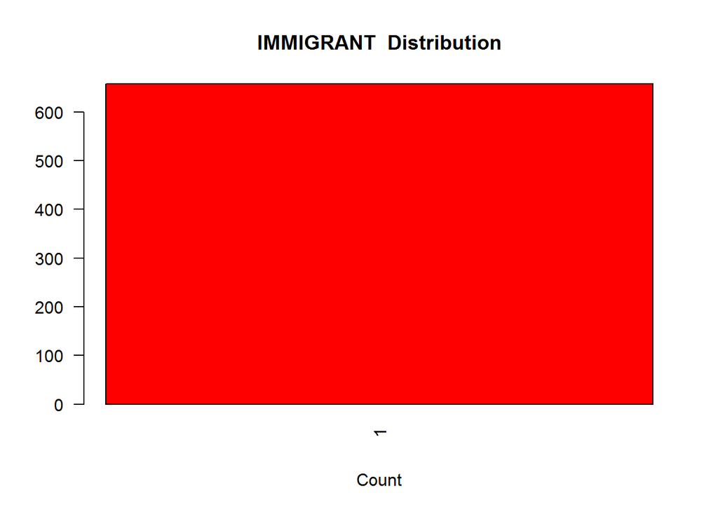

```r
plotDistr <- function (val, frm){
  table <- table(frm[,val])
  barplot(table, main=paste(val, " Distribution"), xlab="Count", col = rainbow(8), las = 2)
}

skips <- c("IDN", "INCOME", "HAPPINESS", "GEN", "AGE")

for(vart in vars){
  if(vart %in% skips){
  } else {
    plotDistr(vart, hap.outliers)
  }
}
```

And the clear similarity between all the outliers is that they’re Immigrants.

Now its time to go and create the same graphs with the new immigrant subset.

### Immigrants

Creating new Immigrant subset and creating graphs

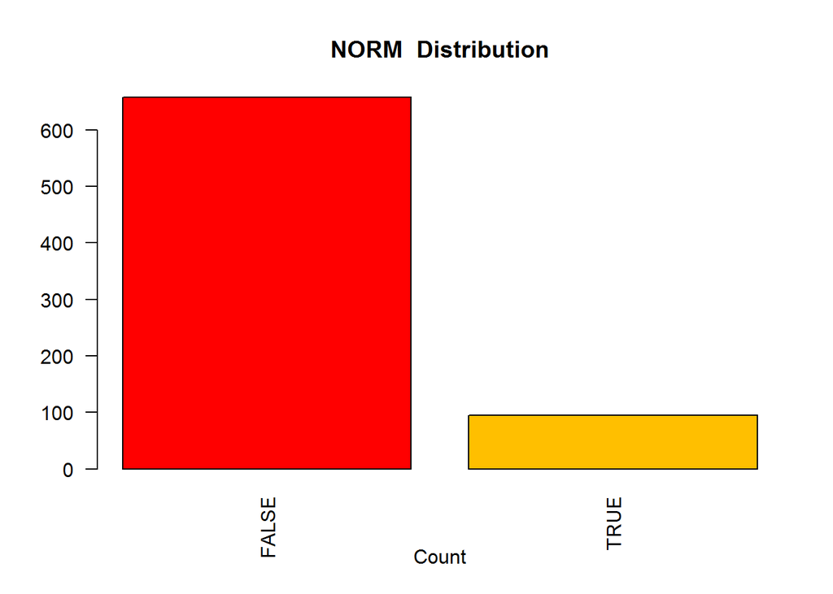

```r
imgrts <- subset(hap, IMMIGRANT == 1)

imgrts[,11] <- ""
colnames(imgrts)[11] <- "NORM"
imgrts$NORM <- (as.numeric(imgrts$HAPLEVEL) == as.numeric(imgrts$INCLEVEL))

plotDistr("NORM", imgrts)
```

Most Immigrants do not fit the “Social Norm”, only about 12.6% fit the normal Income/Happiness Levels.

In an attempt to discover more patterns that might show why immigrants don’t fit the social norm, I re-graphed all the distributions for the Immigrants.

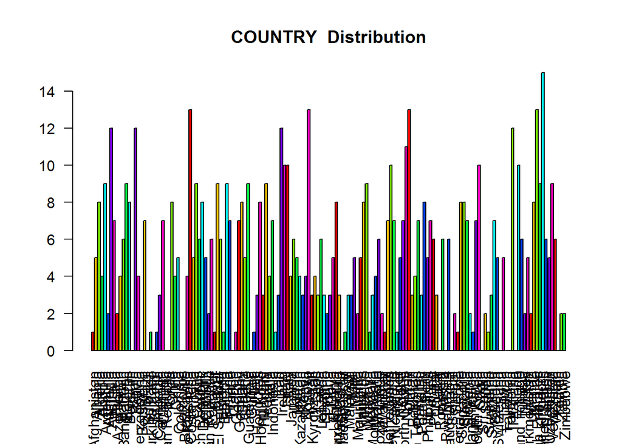

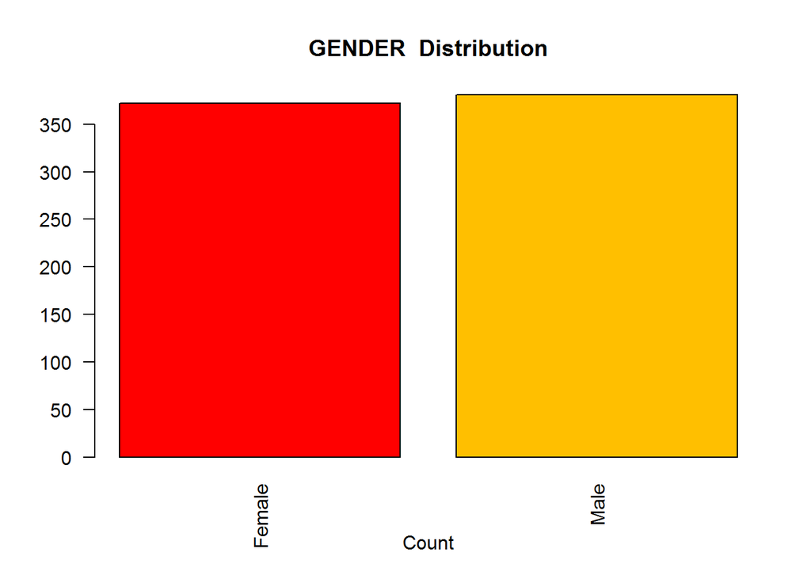

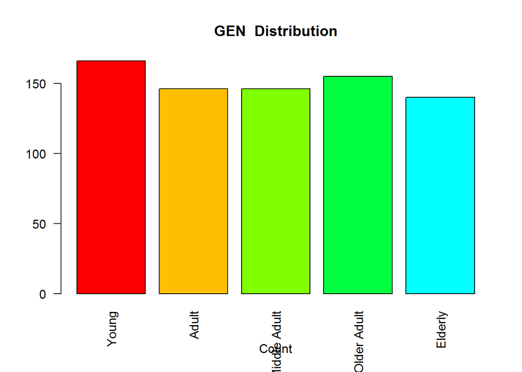

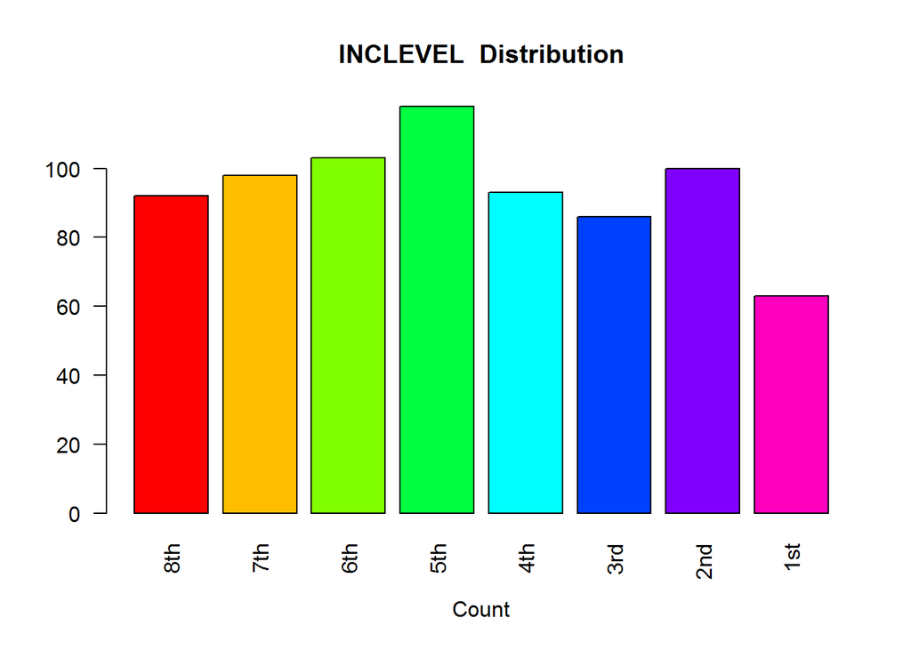

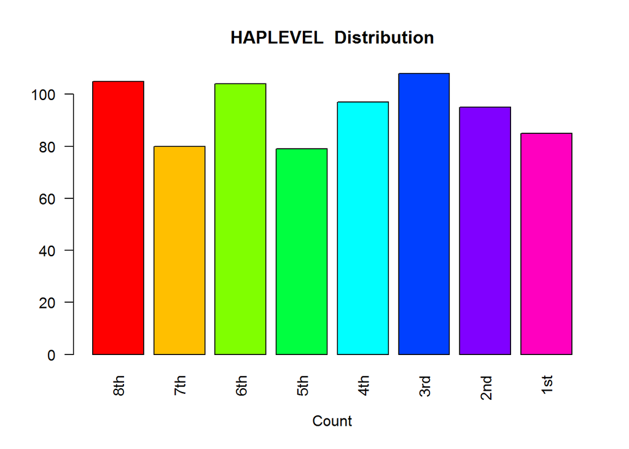

```r
vars = colnames(imgrts)

skips <- c("IDN", "AGE", "IMMIGRANT", "INCOME", "HAPPINESS", "NORM")

for(vart in vars){
  if (vart %in% skips){

  } else {
    plotDistr(vart, imgrts)
  }
}
```

No patterns emerged here, so it would appear that the implanted patterns end here.

## Notes and Comments

This attempt went much more smoothly. I’ve begun to get a better grasp on how to approach analyzing a data set, and have made use of functions and loops to increase my plot speed.

I felt I over thought the last analysis, so I went with a more direct approach this time, and it worked out.

But I think that because this is a synthetic data set, it was easier to over think the analysis. So I look forward to dealing with more random/real world data sets in the future.

Our next project won’t involve a synthetic data set, so I look forward to the new challenges that the next step in analysis presents.

[Rutgers Data 101 Blog](http://data101.cs.rutgers.edu/?q=blog)

My Data Exploration Homepage

[Rutgers Data 101 Homepage](http://data101.cs.rutgers.edu/)